# Complemento Laboratorio Nº7

Análisis de Datos

Profesores: Ramón H. Cornejo-Muñoz y Felipe Rojas Profesor Ayudante de Laboratorio: Mauricio Vargas Ayudantes: Franco Mansilla y Mauricio Díaz Universidad Nacional Andrés Bello

## ¿Por qué usar series de tiempo?

La estacionalidad de los datos y la dependencia entre observaciones ordenadas temporalmente requiere de un análisis para el cuál la teoría ha desarrollado herramientas específicas. El estudio de las series de tiempo se relaciona estrechamente con el estudio de técnicas para analizar la dependencia temporal entre observaciones.

De esto se debe introducir variables rezagadas y en muchas aplicaciones se deben descomponer las series para determinar la componente estacional y la aleatoria que afectan los datos.

En el día a día de cualquier banco o institución financiera las series de tiempo son una herramienta útil.

Librerías necesarias para trabajar con series de tiempo en el contexto financiero

```r
require(forecast);require(ggplot2);require(gridExtra);require(PerformanceAnalytics);require(quantmod);require(Quandl);require(reshape)
```

## Ejemplo: Serie de precios de una acción

### Gráficos y calculo de retornos

Vamos a trabajar con los datos del índice Hang Seng vistos en laboratorio. En estricto rigor este índice es un portafolio (o combinación de distintas acciones) que se puede tomar como una referencia del estado mercado en determinados contextos.

```r
#hk <- Quandl("YAHOO/INDEX_HSI", collapse="monthly", type = "zoo", authcode = "...")
#saveRDS(hk,"hk.RData")
hk <- readRDS("hk.Rdata")
```

Se puede acotar el periodo analizado con el comando `window`

```r
hk <- window(hk, start = '2000-01-01', end = '2015-08-31')
```

Lo primero será graficar la componente estacional y la componente aleatoria de la serie

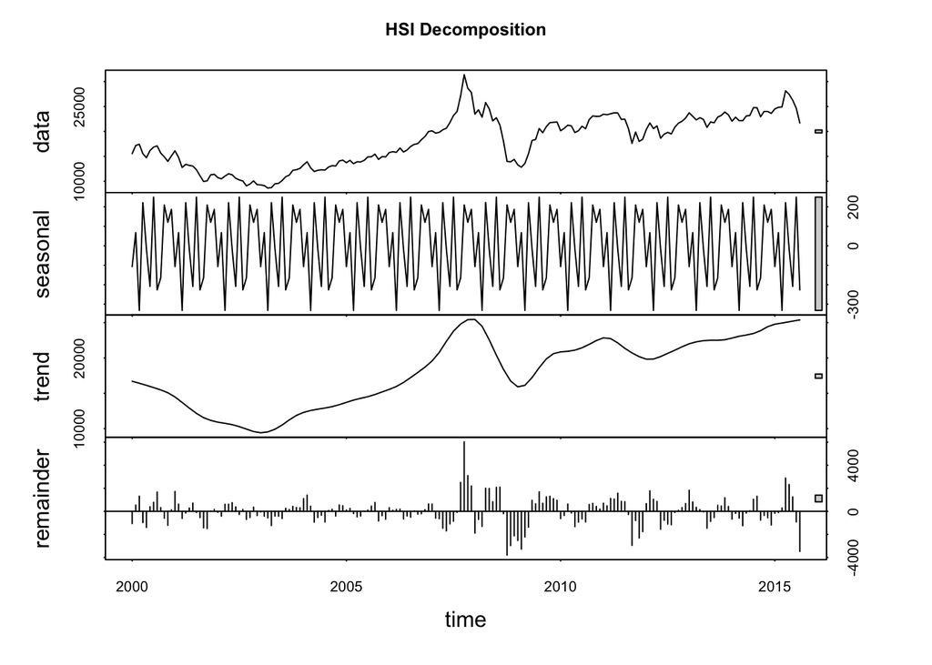

```r
plot(stl(hk[,4],s.window="periodic"), main = "HSI Decomposition")
```

Luego se puede graficar la tendencia usando media móvil de $n$ periodos (usaremos 3 periodos para el ejemplo)

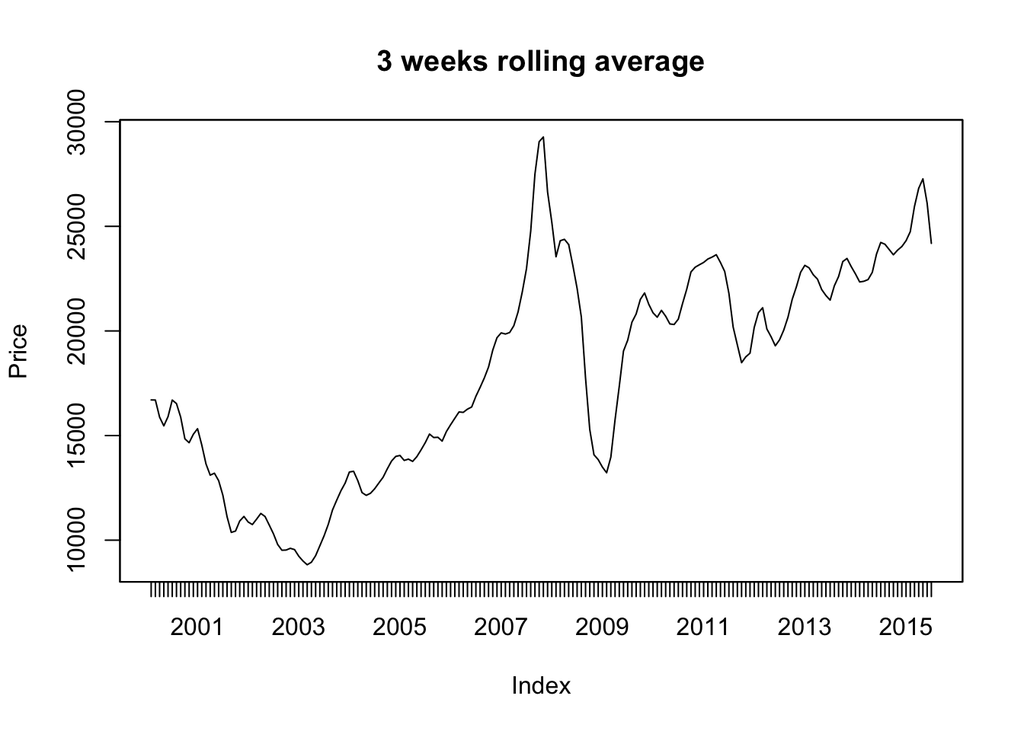

```r
plot(rollapply(hk[,4],3,mean),  main = "3 weeks rolling average", ylab = "Price")
```

`PerformanceAnalytics` permite generar gráficos con un resultado aceptable. La ventaja de esta librería es que realiza automáticamente el cálculo de los retornos y los dropdowns

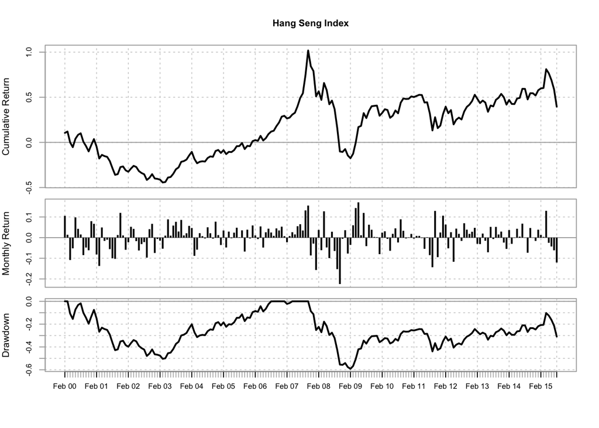

```r
charts.PerformanceSummary(
  ROC(hk[,4], n = 1, type = "discrete"),
  main = "Hang Seng Index"
)
```

Un caso cotidiano de estacionalidad es el retorno de una acción. Por esto el foco de la teoría está en los retornos más que en los precios. Los retornos se pueden calcular como retorno simple o retorno compuesto

```r
ret.simple <- diff(hk[,4]) / lag(hk[,4], k = -1) * 100
ret.compuesto <- diff(log(hk[,4])) * 100
```

Interesa saber como se distribuyen los retornos

```r
summary(coredata(ret.simple))
```

```
##     Min.  1st Qu.   Median     Mean  3rd Qu.     Max.
## -22.4700  -3.1280   0.9586   0.3760   4.2260  17.0700
```

```r
summary(coredata(ret.compuesto))
```

```
##     Min.  1st Qu.   Median     Mean  3rd Qu.     Max.
## -25.4500  -3.1780   0.9540   0.1781   4.1400  15.7600
```

```r
ret.compuesto[which.max(ret.compuesto)]
```

```
## May 2009
## 15.76336
```

Los datos que entrega `summary` permiten construir un histograma para conocer la distruibución de los retornos

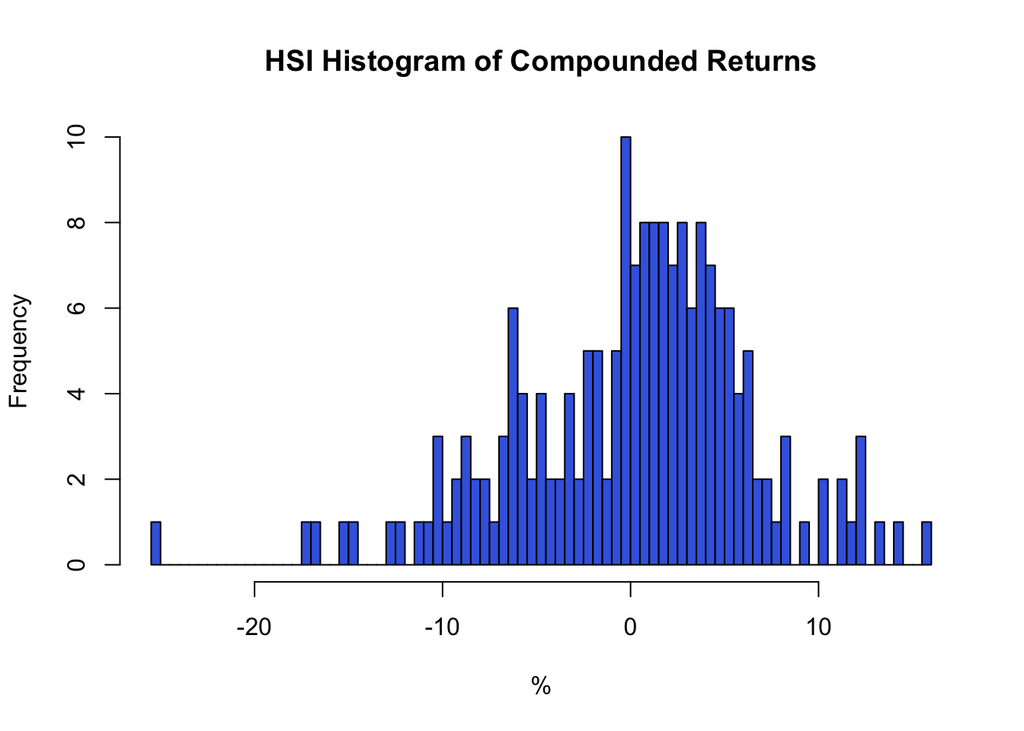

```r
hist(ret.compuesto, breaks=100, main = "HSI Histogram of Compounded Returns", col = "royalblue", xlab="%")
```

Los cuantiles son importantes ya que dan información útil sobre la distribución de los retornos. Se puede determinar la probabilidad de que en un mes el retorno sea inferior al $x$%

```r
quantile(ret.compuesto, probs = 0.01)
```

```
##        1%
## -16.63067
```

### Regresión en el contexto de series de tiempo

Usaremos la metodología de Box & Jenkins (1976) que se agrupa en los modelos ARIMA (Autoregressive Integrated Moving Average) los que asumen que una observación puede depender únicamente de las observaciones anteriores o de valores anteriores de la componente de error.

La metodología consiste en:

1. Identificar el modelo
2. Estimar el modelo
3. Verificar el modelo

Identificación y estimación del modelo. Se puede restringir la estimación a modelos de componente estacionaria o estacional y también se puede buscar el mejor modelo con ambas componentes. Por ahora nos centraremos en el primer caso.

```r
fit1 <- auto.arima(ret.simple, stationary = TRUE, seasonal = FALSE, ic="aic")
summary(fit1)
```

```
## Series: ret.simple
## ARIMA(1,0,0) with zero mean
##
## Coefficients:
##          ar1
##       0.1359
## s.e.  0.0735
##
## sigma^2 estimated as 38.35:  log likelihood=-606.33
## AIC=1216.67   AICc=1216.73   BIC=1223.13
##
## Training set error measures:
##                    ME     RMSE      MAE      MPE     MAPE      MASE
## Training set 0.315634 6.193116 4.803965 107.6781 124.0272 0.7045213
##                       ACF1
## Training set -0.0004371488
```

```r
confint(fit1)
```

```
##            2.5 %    97.5 %
## ar1 -0.008230121 0.2800743
```

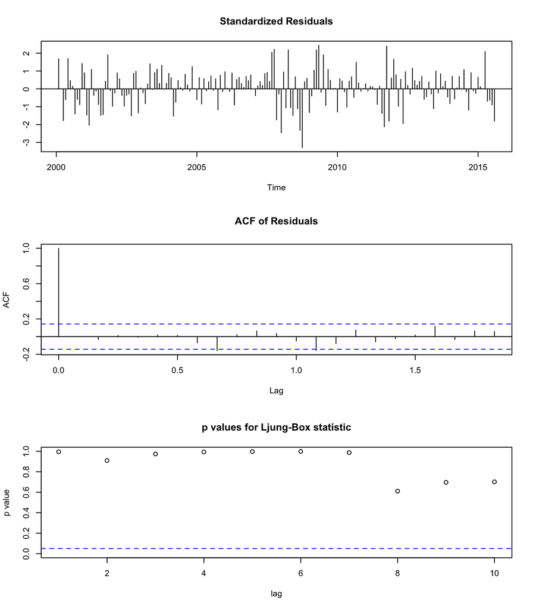

```r
tsdiag(fit1)
```

En el gráfico se observa que los residuos estandarizados no se agrupan en determinados periodos, la autocorrelación entre residuos no es considerable y el test de autocorrelación muestra que los valores $p$ son mayores a 0,1 por lo que no se puede rechazar la hipótesis nula de residuos independientes al 90% de confianza o mayor.

Para ver el ajuste del modelo se puede graficar los datos observados y los estimados

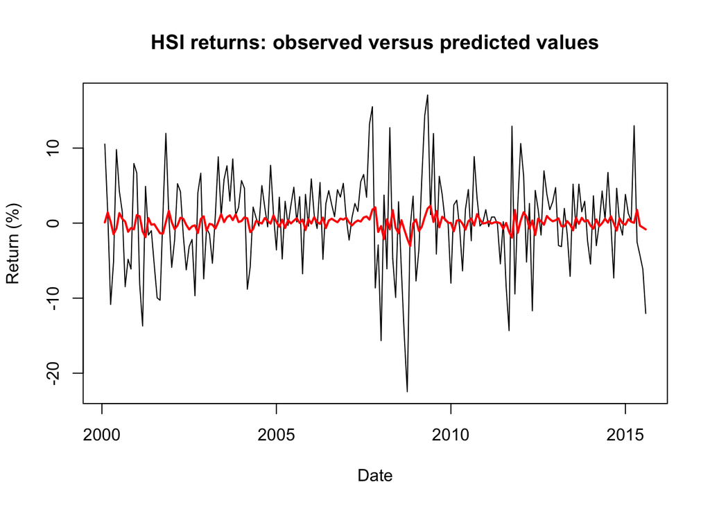

```r
plot(fit1$x, lty = 1, main = "HSI returns: observed versus predicted values", ylab = "Return (%)", xlab = "Date")
lines(fitted(fit1), lty = 1, lwd = 2, col = "red")
```

$\Longrightarrow$ Se debería probar un modelo con componente estacional.

```r
fit2 <- auto.arima(ret.simple, stationary = TRUE, seasonal = TRUE, ic="aic")
summary(fit2)
```

```
## Series: ret.simple
## ARIMA(0,0,0)(2,0,1)[12] with non-zero mean
##
## Coefficients:
##          sar1     sar2    sma1  intercept
##       -0.4118  -0.0779  0.3358     0.3883
## s.e.   0.6499   0.0842  0.6471     0.4110
##
## sigma^2 estimated as 38.58:  log likelihood=-606.95
## AIC=1223.89   AICc=1224.22   BIC=1240.05
##
## Training set error measures:
##                        ME     RMSE      MAE      MPE     MAPE     MASE
## Training set -0.005343331 6.211283 4.739328 100.1896 106.7575 0.695042
##                   ACF1
## Training set 0.1118524
```

```r
confint(fit2)
```

```
##                2.5 %     97.5 %
## sar1      -1.6854459 0.86193594
## sar2      -0.2429583 0.08709199
## sma1      -0.9324539 1.60398313
## intercept -0.4171206 1.19381324
```

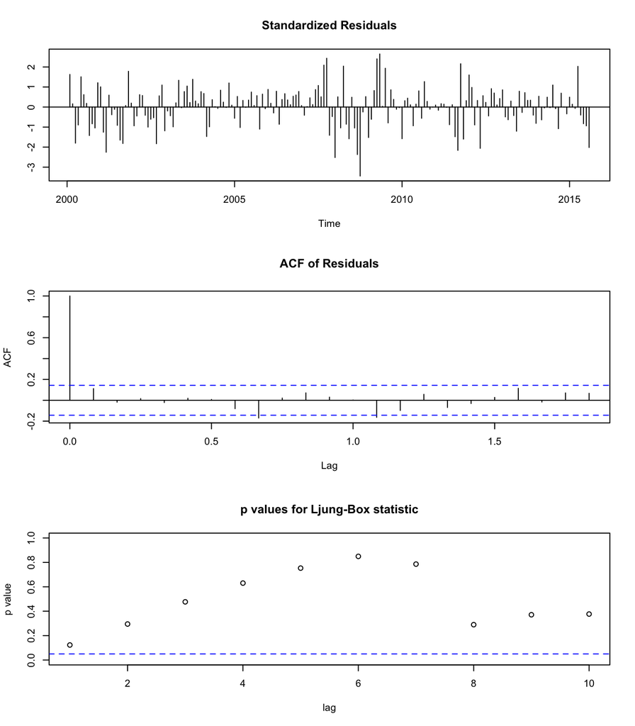

```r
tsdiag(fit2)
```

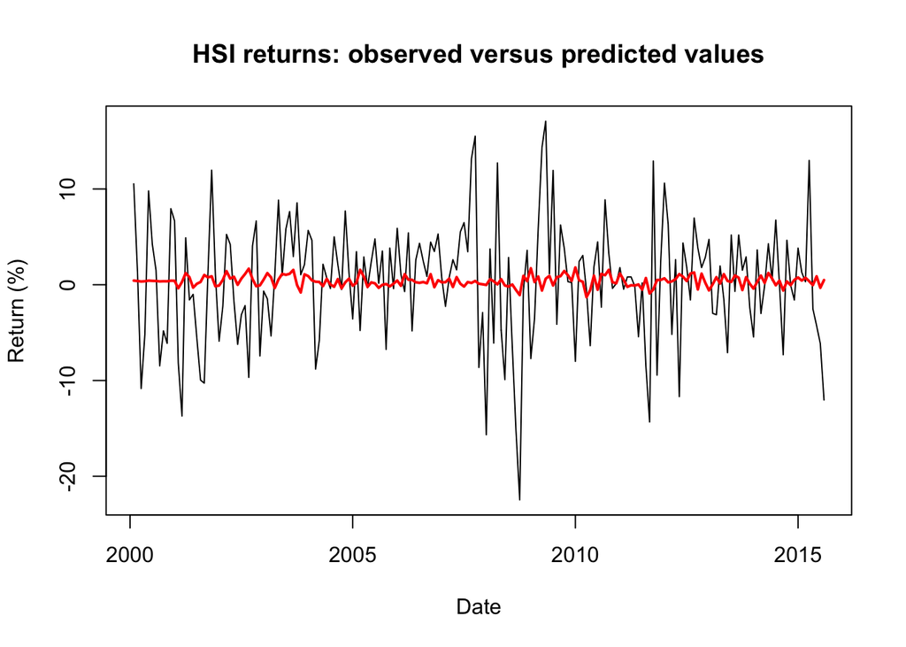

```r
plot(fit2$x, lty = 1, main = "HSI returns: observed versus predicted values", ylab = "Return (%)", xlab = "Date")
lines(fitted(fit2), lty = 1, lwd = 2, col = "red")
```

$\Longrightarrow$ Comparando los indicadores (e.g. RMSE) y los gráficos se prefiere el primer modelo.

```r
predict(fit1, n.ahead=12)
```

```
## $pred
##                Jan           Feb           Mar           Apr           May
## 2015
## 2016 -5.584734e-04 -7.590889e-05 -1.031770e-05 -1.402403e-06 -1.906176e-07
##                Jun           Jul           Aug           Sep           Oct
## 2015                                           -1.636221e+00 -2.223987e-01
## 2016 -2.590914e-08 -3.521626e-09 -4.786668e-10
##                Nov           Dec
## 2015 -3.022890e-02 -4.108776e-03
## 2016
##
## $se
##           Jan      Feb      Mar      Apr      May      Jun      Jul
## 2015
## 2016 6.251129 6.251129 6.251129 6.251129 6.251129 6.251129 6.251129
##           Aug      Sep      Oct      Nov      Dec
## 2015          6.193116 6.250062 6.251109 6.251129
## 2016 6.251129
```

$\Longrightarrow$ Las predicciones tendrán un error estándar en torno el 6% (bastante elevado)